# Projet_Multidim_ACP

N.Bertrand_Gueri

2024-02-21

## Introduction

L’ONG HELP International a réussi à collecter environ 10 millions de dollars, une somme considérable destinée à soutenir des initiatives humanitaires à travers le monde. Face à ce financement, le PDG de l’organisation est confronté à la délicate tâche de déterminer la meilleure stratégie pour l’utiliser de manière efficace et ciblée. Pour ce faire, il doit identifier les pays qui présentent les besoins les plus pressants en termes d’aide humanitaire. En tant que data scientist, notre mission consiste à analyser et à catégoriser les pays en fonction de divers facteurs socio-économiques et sanitaires qui influent sur leur développement global. Cette classification permettra ensuite de recommander au PDG les pays sur lesquels concentrer les efforts de l’ONG afin d’avoir un impact significatif et durable sur les populations les plus vulnérables.

## Objectif

Catégoriser les pays en fonction des facteurs socio-économiques et sanitaires qui déterminent le développement global du pays.

## PARTIE I : TRAITEMENT DES DONNEES BRUTES

Cette partie présente le dictionnaire des données utilisées dans la présente analyse ainsi que les étapes de l’apurement de notre base de données. A cela, il faut ajouter que la méthodologie est basée sur une approche essentiellement descriptive en utilisant le logiciel R pour le traitement et l’analyse des données.

## Dictionnaire des données de l’analyse

Le jeu de données s’appelera “Petrole”. Il comporte des variables tant quantitatives que qualitatives. Ces variables sont listées dans le tableau de dictionnaire de données ci-dessous :

| VARIABLE | NATURE | DESCRIPTION | MODALITES |
| --- | --- | --- | --- |
| Pays | Qualitative | Nom du pays | Chaine de caractère |
| Enfant_mort | Quantitative | Décès d’enfants de moins de 5 ans pour 1000 naissances vivantes | Numerique decimal |
| exportations | Quantitative | Exportations de biens et services par habitant.Donné en pourcentage du PIB par habitant | Numerique decimal |
| dep_sante | Quantitative | Dépenses totales de santé par habitant.Données en pourcentage du PIB par habitant | Numerique decimal |
| importations | Quantitative | Importations de biens et services par habitant. Donné en pourcentage du PIB par habitant | Numerique decimal |
| revenu | Quantitative | Revenu net par personne | Numerique entier |
| taux_croissance | Quantitative | La mesure du taux d’inflation annuel du PIB total | Numerique decimal |
| esperance_vie | Quantitative | Le nombre moyen d’années qu’un nouveau-né vivrait si les tendances de mortalité actuelles devaient rester les mêmes | Numerique decimal |
| total_fertilite | Quantitative | Le nombre d’enfants qui naîtraient à chaque femme si les taux de fécondité par âge actuels devaient rester les mêmes. | Numerique decimal |
| pib_par_hab | Quantitative | Le PIB par habitant. Calculé comme le PIB total divisé par la population totale. | Numerique entier |

## Importation du jeu de donées

|  | enfant_mort | exportations | dep_sante | importations | revenu | taux_croissance | life_expec | total_fertilite | pib_par_hab |
| --- | --- | --- | --- | --- | --- | --- | --- | --- | --- |
| Afghanistan | 90.2 | 10.0 | 7.58 | 44.9 | 1610 | 9.44 | 56.2 | 5.82 | 553 |
| Albania | 16.6 | 28.0 | 6.55 | 48.6 | 9930 | 4.49 | 76.3 | 1.65 | 4090 |
| Algeria | 27.3 | 38.4 | 4.17 | 31.4 | 12900 | 16.10 | 76.5 | 2.89 | 4460 |
| Angola | 119.0 | 62.3 | 2.85 | 42.9 | 5900 | 22.40 | 60.1 | 6.16 | 3530 |
| Antigua and Barbuda | 10.3 | 45.5 | 6.03 | 58.9 | 19100 | 1.44 | 76.8 | 2.13 | 12200 |
| Argentina | 14.5 | 18.9 | 8.10 | 16.0 | 18700 | 20.90 | 75.8 | 2.37 | 10300 |

```
## 'data.frame':    167 obs. of  9 variables:
##  $ enfant_mort    : num  90.2 16.6 27.3 119 10.3 14.5 18.1 4.8 4.3 39.2 ...
##  $ exportations   : num  10 28 38.4 62.3 45.5 18.9 20.8 19.8 51.3 54.3 ...
##  $ dep_sante      : num  7.58 6.55 4.17 2.85 6.03 8.1 4.4 8.73 11 5.88 ...
##  $ importations   : num  44.9 48.6 31.4 42.9 58.9 16 45.3 20.9 47.8 20.7 ...
##  $ revenu         : num  1610 9930 12900 5900 19100 18700 6700 41400 43200 16000 ...
##  $ taux_croissance: num  9.44 4.49 16.1 22.4 1.44 20.9 7.77 1.16 0.873 13.8 ...
##  $ life_expec     : num  56.2 76.3 76.5 60.1 76.8 75.8 73.3 82 80.5 69.1 ...
##  $ total_fertilite: num  5.82 1.65 2.89 6.16 2.13 2.37 1.69 1.93 1.44 1.92 ...
##  $ pib_par_hab    : num  553 4090 4460 3530 12200 10300 3220 51900 46900 5840 ...
```

|  | enfant_mort | exportations | dep_sante | importations | revenu | taux_croissance | life_expec | total_fertilite | pib_par_hab |
| --- | --- | --- | --- | --- | --- | --- | --- | --- | --- |
|  | Min. : 2.60 | Min. : 0.109 | Min. : 1.810 | Min. : 0.0659 | Min. : 49.6 | Min. : -4.21 | Min. : 2.04 | Min. : 1.15 | Min. : 1.47 |
|  | 1st Qu.: 7.85 | 1st Qu.: 23.800 | 1st Qu.: 4.950 | 1st Qu.: 28.8500 | 1st Qu.: 3170.0 | 1st Qu.: 1.81 | 1st Qu.:64.30 | 1st Qu.: 1.82 | 1st Qu.: 1310.00 |
|  | Median : 19.20 | Median : 35.000 | Median : 6.330 | Median : 42.9000 | Median : 9940.0 | Median : 5.45 | Median :73.10 | Median : 2.41 | Median : 4660.00 |
|  | Mean : 37.80 | Mean : 41.353 | Mean : 7.761 | Mean : 45.6223 | Mean : 17023.2 | Mean : 130.49 | Mean :69.30 | Mean : 4.39 | Mean : 12901.54 |
|  | 3rd Qu.: 60.40 | 3rd Qu.: 51.400 | 3rd Qu.: 8.865 | 3rd Qu.: 58.0500 | 3rd Qu.: 22800.0 | 3rd Qu.: 11.15 | 3rd Qu.:76.80 | 3rd Qu.: 4.16 | 3rd Qu.: 14050.00 |
|  | Max. :208.00 | Max. :200.000 | Max. :85.100 | Max. :174.0000 | Max. :125000.0 | Max. :11400.00 | Max. :82.80 | Max. :74.00 | Max. :105000.00 |
|  | NA’s :4 | NA | NA | NA | NA | NA | NA | NA | NA |

Le résumé sommaire de ce jeu de données permet de détecter qu’il existe des données manquantes matérialisées par des valeurs NAs. Ces valeurs doivent passer par une étape de traitement.

## Traitement des valeurs manquantes dans les données

Cette section va servir à afficher les observations qui contiennent des valeurs manquantes. Elle srvira également à réaliser tout le traitement qui y convient.

## Proportion des valeurs manquantes dans les données

|  | Nombre | Proportion |
| --- | --- | --- |
| enfant_mort | 4 | 0.0239521 |
| exportations | 0 | 0.0000000 |
| dep_sante | 0 | 0.0000000 |
| importations | 0 | 0.0000000 |
| revenu | 0 | 0.0000000 |
| taux_croissance | 0 | 0.0000000 |
| life_expec | 0 | 0.0000000 |
| total_fertilite | 0 | 0.0000000 |
| pib_par_hab | 0 | 0.0000000 |

[output not shown]

```
## VIM is ready to use.
```

```
## Suggestions and bug-reports can be submitted at: https://github.com/statistikat/VIM/issues
```

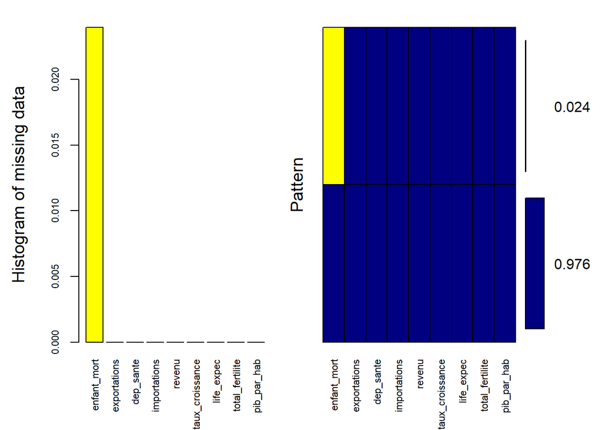

```
##
##  Variables sorted by number of missings:
##         Variable     Count
##      enfant_mort 0.0239521
##     exportations 0.0000000
##        dep_sante 0.0000000
##     importations 0.0000000
##           revenu 0.0000000
##  taux_croissance 0.0000000
##       life_expec 0.0000000
##  total_fertilite 0.0000000
##      pib_par_hab 0.0000000
```

Et puisque la technique de l’ACP ne tolère pas les données manquantes, il convient donc de procéder au traitement de ces valeurs pour leur imputation, plutôt que de les supprimer de notre base de données.

```
##   rows columns discrete_columns continuous_columns all_missing_columns
## 1  167       9                0                  9                   0
##   total_missing_values complete_rows total_observations memory_usage
## 1                    4           163               1503        14944
```

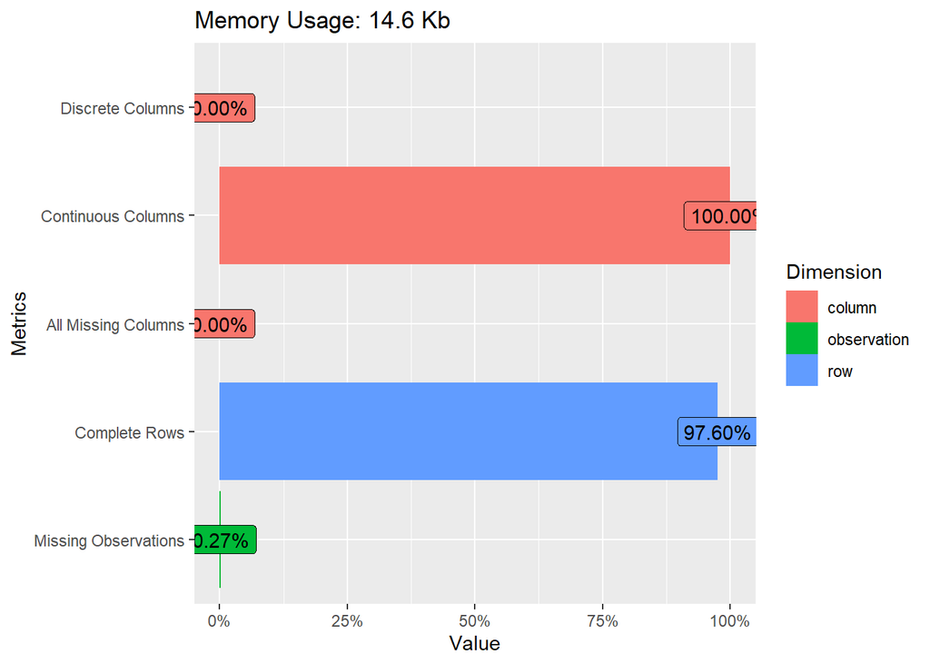

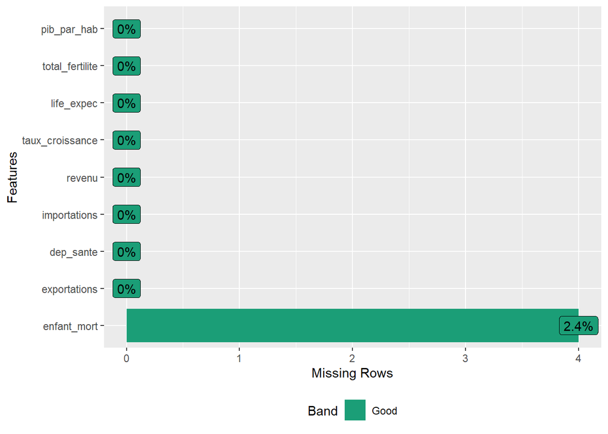

## Imputation de données manquantes par les K plus proches voisins

Nous avons d’abord dupliqué le jeu de données en le renommant “Multidim1” puis avons procédé à l’annulation de la variable qualitative puisque nous sommes dans un ACP.

Pour l’imputation des valeurs manquantes parmi les variables quantitatives, nous avons avons utilisé la technique des K plus proches voisins consistant à remplir les valeurs manquantes en explorant les similitudes entre les cas. Ceci du fait que nous essayons de trouver les valeurs les plus probables pour chacune de ces inconnues. Pour mesurer donc cette proximité entre les observations, nous avons opté pour l’application d’une fonction de similarité reposant sur un calcul de distance. Cette fonction qui calcule la distance entre deux observations estime l’affinité entre les observations comme ceci : « Plus deux points sont proches l’un de l’autre, plus ils sont similaires. » Nous avons donc conservé les 50 observations du jeu de données qui sont les plus « proches » des observations à prédire. Par la suite nous nous sommes évertué à retrouver à quelle famille appartient les nouvelles données, en cherchant la famille sinon la classe majoritaire parmi les k données. Et nous avons retourné la valeur calculée comme étant la valeur qui a été prédite pour l’observation en entrée qui était inconnue.

Ci-dessous un bref aperçu des nouvelles données quantitatives après imputation des valeurs manquantes.

|  | enfant_mort | exportations | dep_sante | importations | revenu | taux_croissance | life_expec | total_fertilite | pib_par_hab |
| --- | --- | --- | --- | --- | --- | --- | --- | --- | --- |
| Afghanistan | 90.2 | 10.0 | 7.58 | 44.9 | 1610 | 9.44 | 56.2 | 5.82 | 553 |
| Albania | 16.6 | 28.0 | 6.55 | 48.6 | 9930 | 4.49 | 76.3 | 1.65 | 4090 |
| Algeria | 27.3 | 38.4 | 4.17 | 31.4 | 12900 | 16.10 | 76.5 | 2.89 | 4460 |
| Angola | 119.0 | 62.3 | 2.85 | 42.9 | 5900 | 22.40 | 60.1 | 6.16 | 3530 |
| Antigua and Barbuda | 10.3 | 45.5 | 6.03 | 58.9 | 19100 | 1.44 | 76.8 | 2.13 | 12200 |
| Argentina | 14.5 | 18.9 | 8.10 | 16.0 | 18700 | 20.90 | 75.8 | 2.37 | 10300 |

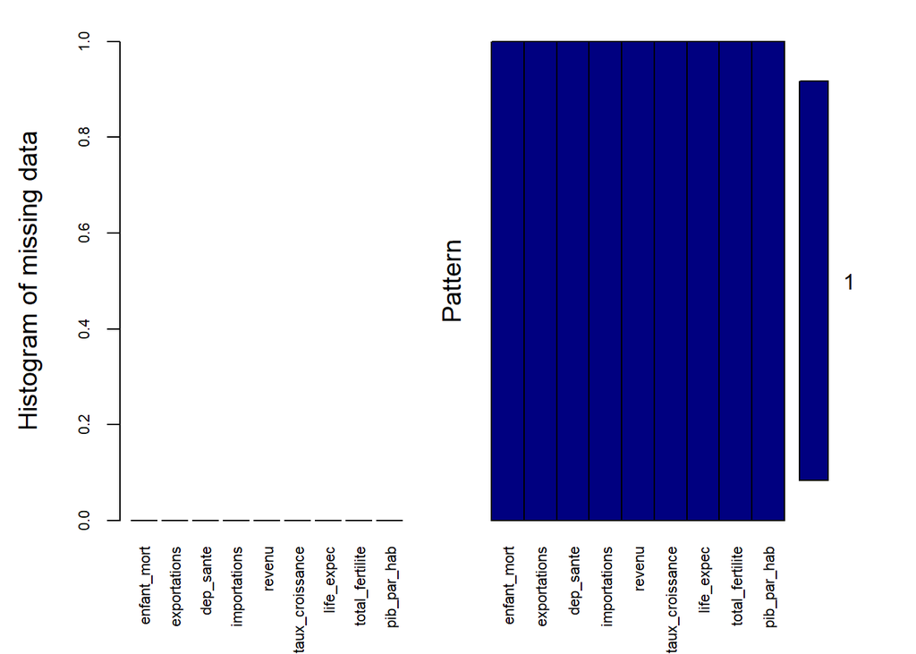

```
##
##  Variables sorted by number of missings:
##         Variable Count
##      enfant_mort     0
##     exportations     0
##        dep_sante     0
##     importations     0
##           revenu     0
##  taux_croissance     0
##       life_expec     0
##  total_fertilite     0
##      pib_par_hab     0
```

|  | enfant_mort | exportations | dep_sante | importations | revenu | taux_croissance | life_expec | total_fertilite | pib_par_hab |
| --- | --- | --- | --- | --- | --- | --- | --- | --- | --- |
|  | Min. : 2.60 | Min. : 0.109 | Min. : 1.810 | Min. : 0.0659 | Min. : 49.6 | Min. : -4.21 | Min. : 2.04 | Min. : 1.15 | Min. : 1.47 |
|  | 1st Qu.: 8.25 | 1st Qu.: 23.800 | 1st Qu.: 4.950 | 1st Qu.: 28.8500 | 1st Qu.: 3170.0 | 1st Qu.: 1.81 | 1st Qu.:64.30 | 1st Qu.: 1.82 | 1st Qu.: 1310.00 |
|  | Median : 19.70 | Median : 35.000 | Median : 6.330 | Median : 42.9000 | Median : 9940.0 | Median : 5.45 | Median :73.10 | Median : 2.41 | Median : 4660.00 |
|  | Mean : 39.25 | Mean : 41.353 | Mean : 7.761 | Mean : 45.6223 | Mean : 17023.2 | Mean : 130.49 | Mean :69.30 | Mean : 4.39 | Mean : 12901.54 |
|  | 3rd Qu.: 62.40 | 3rd Qu.: 51.400 | 3rd Qu.: 8.865 | 3rd Qu.: 58.0500 | 3rd Qu.: 22800.0 | 3rd Qu.: 11.15 | 3rd Qu.:76.80 | 3rd Qu.: 4.16 | 3rd Qu.: 14050.00 |
|  | Max. :208.00 | Max. :200.000 | Max. :85.100 | Max. :174.0000 | Max. :125000.0 | Max. :11400.00 | Max. :82.80 | Max. :74.00 | Max. :105000.00 |

## Traitement des valeurs aberrantes et extrêmes

Une seconde étape de l’exploration des données disponibles nous a conduit à traiter les valeurs aberrantes et extrêmes sur les variables quantitatives. Nous appelons valeur aberrante une valeur ou une observation qui est « distante » des autres observations effectuées sur le même phénomène, c’est-à-dire qu’elle contraste grandement avec les valeurs « normalement » mesurées. Leur présence dans les données peut conduire à des estimateurs de paramètres biaisés et, suite à la réalisation de tests statistiques, à une interprétation des résultats erronée. Pouvant être dû à plusieurs facteurs, nous avons pensé utile dans un premier temps de les detecter, puis de les imputer si elles existaient dans notre base de données. La détection desdites données est perceptible comme l’on peut le voir sur notre graphe. Nous avons utilisé les boite à moustache afin de visualiser les débordements observés.

## Détection visuelle des valeurs aberrantes et extrêmes

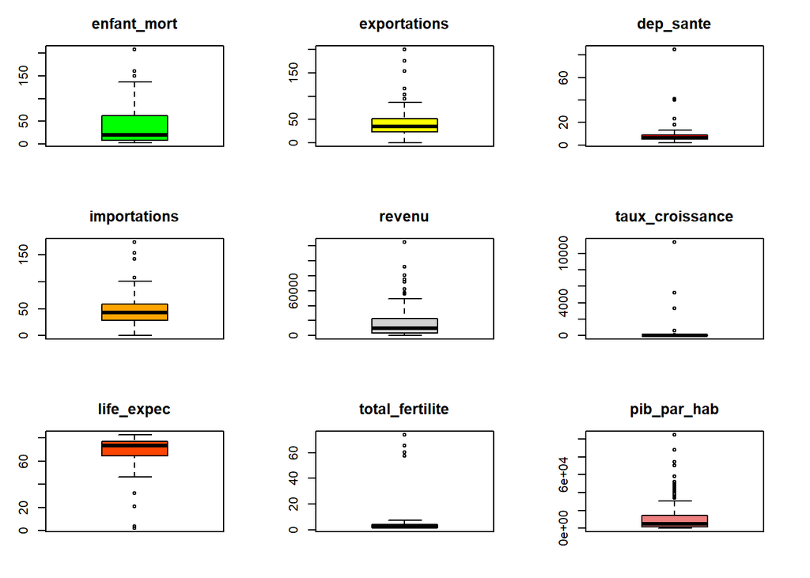

## Technique d’imputation de données abérrantes par winzorisation

Pour le traitement des données extrêmes nous avons utilisé la technique de Winzorisation en les ramenant dans les limites des bornes (inférieure et supérieure) des moutâches.

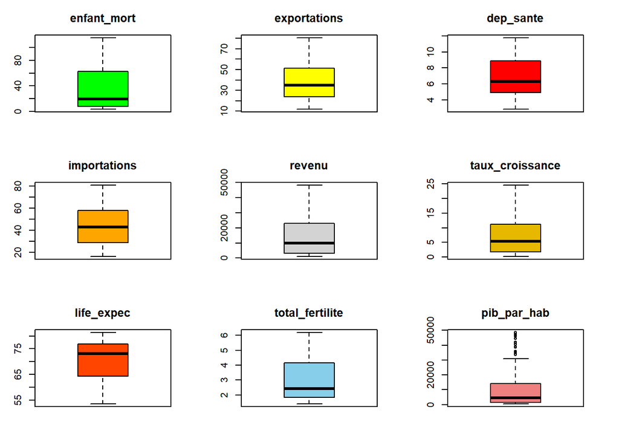

## PARTIE II : ANALYSE EN COMPOSANTES PRINCIPALES (ACP)

Dans cette partie nous allons réaliser l’ACP. Mais avant, nous avons souhaité baliser notre étude avec quelques visualisations préalables afin de justifier notre démarche.

## Préalable à l’ACP

Nous avons décidé de visualiser le sens de la distribution de nos données. Cette étape nous donnera la possibilité de normaliser les données au besoin.

## Visualisation de la distribution des données

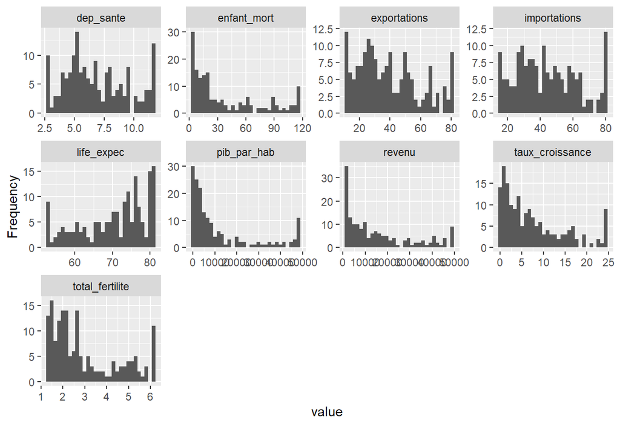

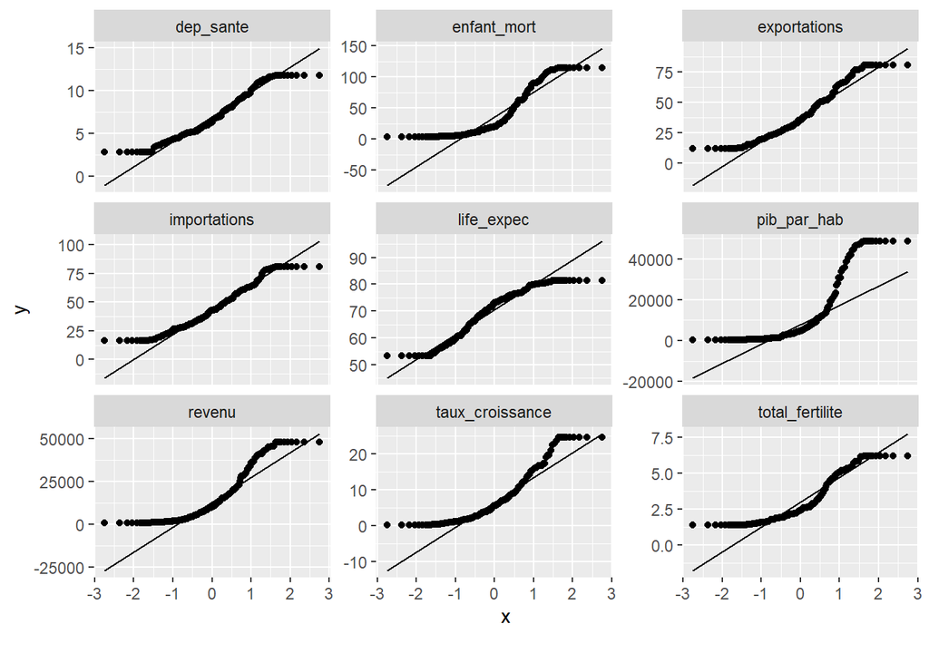